# R Notebook

# Introduction

In this analysis we will extract the data for European countries from the gapminder dataset and discover which countries have the lowest correlation between time and life expectancy. In order to follow the code, you will need to install the following R packages.

```r
install.packages("readr")
install.packages("dplyr")
install.packages("ggplot2")
```

We load the required packages to make the functions we need available.

```r
library(readr)
library(dplyr)
library(ggplot2)
```

The raw data can be found in the file `gapminder.csv`. As this is a *comma-separated* file we will use the function `read_csv` to import the data

```r
gapminder <- read_csv("gapminder.csv")
```

## Filtering the data

We filter the data by requiring the value in the `continent` column is equal to *Europe*. Should we require the data at a later date we can write a csv file.

```r
e_data <- filter(gapminder, continent == "Europe")
write_csv(e_data, path="gapminder_europe.csv")
```

## Calculating the correlations

The correlations can be calculated by first grouping the data according to the name of the country and summarising using the `cor` function between the `year` and `lifeExp` variables. This calculates the Pearson correlation which is a value between -1 and 1.

```r
group_by(e_data,country) %>%
  summarise(Cor = cor(year, lifeExp)) %>%
  arrange(Cor)
```

| country | Cor |
| --- | --- |
| Bulgaria | 0.7392849 |
| Slovak Republic | 0.8898023 |
| Hungary | 0.8916382 |
| Montenegro | 0.8954693 |
| Romania | 0.8975337 |
| Poland | 0.9163314 |
| Serbia | 0.9374462 |
| Bosnia and Herzegovina | 0.9464134 |
| Albania | 0.9542420 |
| Czech Republic | 0.9574351 |

[output cut: 20 more lines]

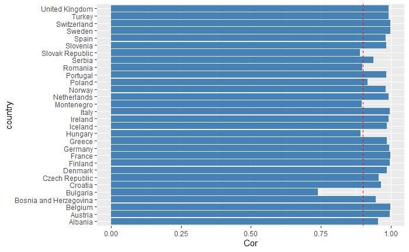

## Summary

There are 5 countries with correlation less than 0.9.